# Risk Factor Analysis

## Outcome Variable

**Outcome Variable:** ever_stunted

## Predictor Variables

**Intervention Variable:** anywast06

**Adjustment Set:**

- arm
- sex
- W_mage
- meducyrs
- W_mhtcm
- month
- brthmon
- W_parity
- delta_W_mage
- delta_meducyrs
- delta_W_mhtcm
- delta_month
- delta_brthmon
- delta_W_parity

## Stratifying Variables

The analysis was stratified on these variable(s):

- agecat
- studyid
- country

## Data Summary

| agecat | studyid | country | anywast06 | ever_stunted | n_cell | n |
| --- | --- | --- | --- | --- | --- | --- |
| 0-6 months | ki0047075b-MAL-ED | BANGLADESH | 0 | 0 | 168 | 263 |
| 0-6 months | ki0047075b-MAL-ED | BANGLADESH | 0 | 1 | 36 | 263 |
| 0-6 months | ki0047075b-MAL-ED | BANGLADESH | 1 | 0 | 49 | 263 |
| 0-6 months | ki0047075b-MAL-ED | BANGLADESH | 1 | 1 | 10 | 263 |
| 0-6 months | ki0047075b-MAL-ED | BRAZIL | 0 | 0 | 194 | 233 |
| 0-6 months | ki0047075b-MAL-ED | BRAZIL | 0 | 1 | 25 | 233 |
| 0-6 months | ki0047075b-MAL-ED | BRAZIL | 1 | 0 | 14 | 233 |
| 0-6 months | ki0047075b-MAL-ED | BRAZIL | 1 | 1 | 0 | 233 |
| 0-6 months | ki0047075b-MAL-ED | INDIA | 0 | 0 | 144 | 251 |
| 0-6 months | ki0047075b-MAL-ED | INDIA | 0 | 1 | 28 | 251 |
| 0-6 months | ki0047075b-MAL-ED | INDIA | 1 | 0 | 65 | 251 |
| 0-6 months | ki0047075b-MAL-ED | INDIA | 1 | 1 | 14 | 251 |
| 0-6 months | ki0047075b-MAL-ED | NEPAL | 0 | 0 | 177 | 240 |
| 0-6 months | ki0047075b-MAL-ED | NEPAL | 0 | 1 | 19 | 240 |
| 0-6 months | ki0047075b-MAL-ED | NEPAL | 1 | 0 | 35 | 240 |
| 0-6 months | ki0047075b-MAL-ED | NEPAL | 1 | 1 | 9 | 240 |
| 0-6 months | ki0047075b-MAL-ED | PERU | 0 | 0 | 258 | 302 |
| 0-6 months | ki0047075b-MAL-ED | PERU | 0 | 1 | 33 | 302 |
| 0-6 months | ki0047075b-MAL-ED | PERU | 1 | 0 | 8 | 302 |
| 0-6 months | ki0047075b-MAL-ED | PERU | 1 | 1 | 3 | 302 |
| 0-6 months | ki0047075b-MAL-ED | SOUTH AFRICA | 0 | 0 | 251 | 313 |
| 0-6 months | ki0047075b-MAL-ED | SOUTH AFRICA | 0 | 1 | 27 | 313 |
| 0-6 months | ki0047075b-MAL-ED | SOUTH AFRICA | 1 | 0 | 29 | 313 |
| 0-6 months | ki0047075b-MAL-ED | SOUTH AFRICA | 1 | 1 | 6 | 313 |
| 0-6 months | ki0047075b-MAL-ED | TANZANIA, UNITED REPUBLIC OF | 0 | 0 | 210 | 261 |
| 0-6 months | ki0047075b-MAL-ED | TANZANIA, UNITED REPUBLIC OF | 0 | 1 | 40 | 261 |
| 0-6 months | ki0047075b-MAL-ED | TANZANIA, UNITED REPUBLIC OF | 1 | 0 | 9 | 261 |
| 0-6 months | ki0047075b-MAL-ED | TANZANIA, UNITED REPUBLIC OF | 1 | 1 | 2 | 261 |
| 0-6 months | ki1000108-CMC-V-BCS-2002 | INDIA | 0 | 0 | 137 | 368 |
| 0-6 months | ki1000108-CMC-V-BCS-2002 | INDIA | 0 | 1 | 37 | 368 |

[output cut: 198 more lines]

The following strata were considered:

- agecat: 0-24 months, studyid: ki0047075b-MAL-ED, country: BANGLADESH
- agecat: 0-24 months, studyid: ki0047075b-MAL-ED, country: BRAZIL
- agecat: 0-24 months, studyid: ki0047075b-MAL-ED, country: INDIA
- agecat: 0-24 months, studyid: ki0047075b-MAL-ED, country: NEPAL
- agecat: 0-24 months, studyid: ki0047075b-MAL-ED, country: PERU
- agecat: 0-24 months, studyid: ki0047075b-MAL-ED, country: SOUTH AFRICA
- agecat: 0-24 months, studyid: ki0047075b-MAL-ED, country: TANZANIA, UNITED REPUBLIC OF
- agecat: 0-24 months, studyid: ki1000108-CMC-V-BCS-2002, country: INDIA
- agecat: 0-24 months, studyid: ki1000108-IRC, country: INDIA
- agecat: 0-24 months, studyid: ki1000109-EE, country: PAKISTAN
- agecat: 0-24 months, studyid: ki1000109-ResPak, country: PAKISTAN
- agecat: 0-24 months, studyid: ki1017093b-PROVIDE, country: BANGLADESH
- agecat: 0-24 months, studyid: ki1066203-TanzaniaChild2, country: TANZANIA, UNITED REPUBLIC OF
- agecat: 0-24 months, studyid: ki1101329-Keneba, country: GAMBIA
- agecat: 0-24 months, studyid: ki1112895-Guatemala BSC, country: GUATEMALA
- agecat: 0-24 months, studyid: ki1113344-GMS-Nepal, country: NEPAL
- agecat: 0-24 months, studyid: ki1114097-CMIN, country: BANGLADESH
- agecat: 0-24 months, studyid: ki1114097-CMIN, country: PERU
- agecat: 0-24 months, studyid: ki1114097-CONTENT, country: PERU
- agecat: 0-6 months, studyid: ki0047075b-MAL-ED, country: BANGLADESH
- agecat: 0-6 months, studyid: ki0047075b-MAL-ED, country: BRAZIL
- agecat: 0-6 months, studyid: ki0047075b-MAL-ED, country: INDIA
- agecat: 0-6 months, studyid: ki0047075b-MAL-ED, country: NEPAL
- agecat: 0-6 months, studyid: ki0047075b-MAL-ED, country: PERU
- agecat: 0-6 months, studyid: ki0047075b-MAL-ED, country: SOUTH AFRICA
- agecat: 0-6 months, studyid: ki0047075b-MAL-ED, country: TANZANIA, UNITED REPUBLIC OF
- agecat: 0-6 months, studyid: ki1000108-CMC-V-BCS-2002, country: INDIA
- agecat: 0-6 months, studyid: ki1000108-IRC, country: INDIA
- agecat: 0-6 months, studyid: ki1000109-EE, country: PAKISTAN
- agecat: 0-6 months, studyid: ki1000109-ResPak, country: PAKISTAN
- agecat: 0-6 months, studyid: ki1017093b-PROVIDE, country: BANGLADESH
- agecat: 0-6 months, studyid: ki1066203-TanzaniaChild2, country: TANZANIA, UNITED REPUBLIC OF
- agecat: 0-6 months, studyid: ki1101329-Keneba, country: GAMBIA
- agecat: 0-6 months, studyid: ki1112895-Guatemala BSC, country: GUATEMALA
- agecat: 0-6 months, studyid: ki1113344-GMS-Nepal, country: NEPAL
- agecat: 0-6 months, studyid: ki1114097-CMIN, country: BANGLADESH
- agecat: 0-6 months, studyid: ki1114097-CMIN, country: PERU
- agecat: 0-6 months, studyid: ki1114097-CONTENT, country: PERU
- agecat: 6-24 months, studyid: ki0047075b-MAL-ED, country: BANGLADESH
- agecat: 6-24 months, studyid: ki0047075b-MAL-ED, country: BRAZIL
- agecat: 6-24 months, studyid: ki0047075b-MAL-ED, country: INDIA
- agecat: 6-24 months, studyid: ki0047075b-MAL-ED, country: NEPAL
- agecat: 6-24 months, studyid: ki0047075b-MAL-ED, country: PERU
- agecat: 6-24 months, studyid: ki0047075b-MAL-ED, country: SOUTH AFRICA
- agecat: 6-24 months, studyid: ki0047075b-MAL-ED, country: TANZANIA, UNITED REPUBLIC OF
- agecat: 6-24 months, studyid: ki1000108-CMC-V-BCS-2002, country: INDIA
- agecat: 6-24 months, studyid: ki1000108-IRC, country: INDIA
- agecat: 6-24 months, studyid: ki1000109-EE, country: PAKISTAN
- agecat: 6-24 months, studyid: ki1000109-ResPak, country: PAKISTAN
- agecat: 6-24 months, studyid: ki1017093b-PROVIDE, country: BANGLADESH
- agecat: 6-24 months, studyid: ki1066203-TanzaniaChild2, country: TANZANIA, UNITED REPUBLIC OF
- agecat: 6-24 months, studyid: ki1101329-Keneba, country: GAMBIA
- agecat: 6-24 months, studyid: ki1112895-Guatemala BSC, country: GUATEMALA
- agecat: 6-24 months, studyid: ki1113344-GMS-Nepal, country: NEPAL
- agecat: 6-24 months, studyid: ki1114097-CMIN, country: BANGLADESH
- agecat: 6-24 months, studyid: ki1114097-CMIN, country: PERU
- agecat: 6-24 months, studyid: ki1114097-CONTENT, country: PERU

### Dropped Strata

Some strata were dropped due to rare outcomes:

- agecat: 0-6 months, studyid: ki0047075b-MAL-ED, country: BRAZIL
- agecat: 0-6 months, studyid: ki0047075b-MAL-ED, country: PERU
- agecat: 0-6 months, studyid: ki0047075b-MAL-ED, country: TANZANIA, UNITED REPUBLIC OF
- agecat: 0-6 months, studyid: ki1112895-Guatemala BSC, country: GUATEMALA
- agecat: 0-6 months, studyid: ki1114097-CONTENT, country: PERU
- agecat: 6-24 months, studyid: ki0047075b-MAL-ED, country: BRAZIL
- agecat: 6-24 months, studyid: ki0047075b-MAL-ED, country: PERU
- agecat: 6-24 months, studyid: ki0047075b-MAL-ED, country: TANZANIA, UNITED REPUBLIC OF
- agecat: 6-24 months, studyid: ki1112895-Guatemala BSC, country: GUATEMALA
- agecat: 6-24 months, studyid: ki1114097-CONTENT, country: PERU
- agecat: 0-24 months, studyid: ki0047075b-MAL-ED, country: BRAZIL
- agecat: 0-24 months, studyid: ki0047075b-MAL-ED, country: PERU
- agecat: 0-24 months, studyid: ki0047075b-MAL-ED, country: TANZANIA, UNITED REPUBLIC OF
- agecat: 0-24 months, studyid: ki1112895-Guatemala BSC, country: GUATEMALA
- agecat: 0-24 months, studyid: ki1114097-CONTENT, country: PERU

## Methods Detail

We’re interested in the causal parameters $E[Y_a]$ for all values of $a \in \mathcal{A}$. These parameters represent the mean outcome if, possibly contrary to fact, we intervened to set all units to have $A=a$. Under the randomization and positivity assumptions, these are identified by the statistical parameters $\psi_a=E_W[E_{Y|A,W}(Y|A=a,W)]$. In addition, we’re interested in the mean of $Y$, $E[Y]$ under no intervention (the observed mean). We will estimate these parameters by using SuperLearner to fit the relevant likelihood factors – $E_{Y|A,W}(Y|A=a,W)$ and $p(A=a|W)$, and then updating our likelihood fit using a joint TMLE.

For unadjusted analyses ($W=\{\}$), initial likelihoods were estimated using Lrnr_glm to estimate the simple $E(Y|A)$ and Lrnr_mean to estimate $p(A)$. For adjusted analyses, a small library containing Lrnr_glmnet, Lrnr_xgboost, and Lrnr_mean was used.

Having estimated these parameters, we will then use the delta method to estimate relative risks and attributable risks relative to a prespecified baseline level of $A$.

# Results Detail

## Results Plots

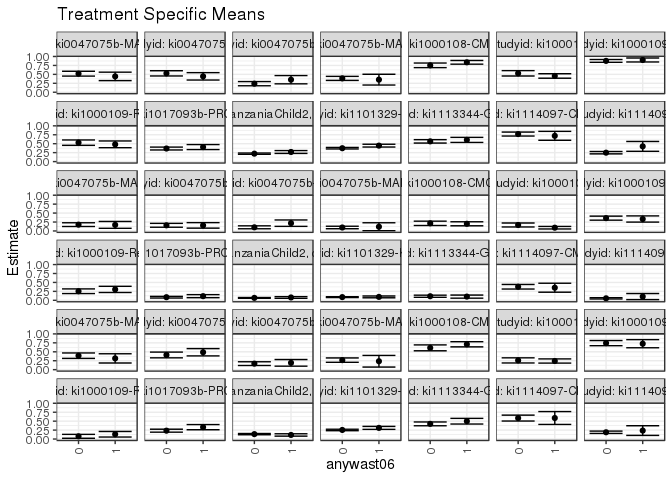

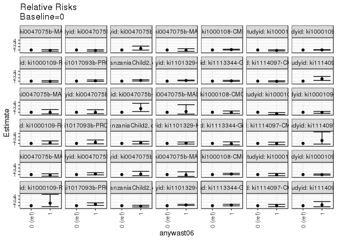

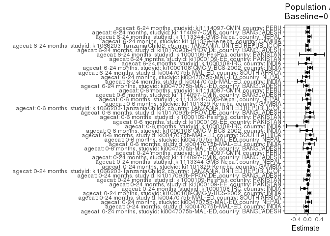

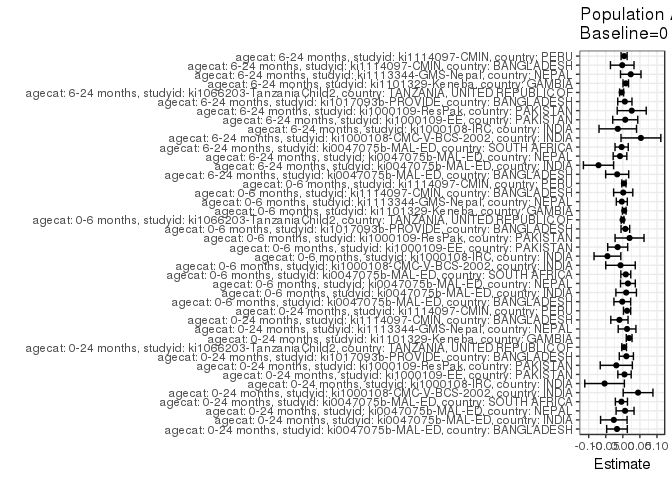

## Results Table

### Parameter: TSM

| agecat | studyid | country | intervention_level | baseline_level | estimate | ci_lower | ci_upper |
| --- | --- | --- | --- | --- | --- | --- | --- |
| 0-24 months | ki0047075b-MAL-ED | BANGLADESH | 0 | NA | 0.5189610 | 0.4517559 | 0.5861660 |
| 0-24 months | ki0047075b-MAL-ED | BANGLADESH | 1 | NA | 0.4430664 | 0.3254390 | 0.5606939 |
| 0-24 months | ki0047075b-MAL-ED | INDIA | 0 | NA | 0.5283498 | 0.4551331 | 0.6015666 |
| 0-24 months | ki0047075b-MAL-ED | INDIA | 1 | NA | 0.4446969 | 0.3417412 | 0.5476526 |
| 0-24 months | ki0047075b-MAL-ED | NEPAL | 0 | NA | 0.2392725 | 0.1803168 | 0.2982283 |
| 0-24 months | ki0047075b-MAL-ED | NEPAL | 1 | NA | 0.3507744 | 0.2351835 | 0.4663652 |
| 0-24 months | ki0047075b-MAL-ED | SOUTH AFRICA | 0 | NA | 0.3874861 | 0.3309737 | 0.4439985 |
| 0-24 months | ki0047075b-MAL-ED | SOUTH AFRICA | 1 | NA | 0.3519501 | 0.2016593 | 0.5022409 |
| 0-24 months | ki1000108-CMC-V-BCS-2002 | INDIA | 0 | NA | 0.7520850 | 0.6880161 | 0.8161540 |
| 0-24 months | ki1000108-CMC-V-BCS-2002 | INDIA | 1 | NA | 0.8363882 | 0.7845885 | 0.8881879 |
| 0-24 months | ki1000108-IRC | INDIA | 0 | NA | 0.5290562 | 0.4541406 | 0.6039718 |
| 0-24 months | ki1000108-IRC | INDIA | 1 | NA | 0.4549089 | 0.3927151 | 0.5171027 |
| 0-24 months | ki1000109-EE | PAKISTAN | 0 | NA | 0.8763300 | 0.8374029 | 0.9152572 |
| 0-24 months | ki1000109-EE | PAKISTAN | 1 | NA | 0.9021079 | 0.8467679 | 0.9574479 |
| 0-24 months | ki1000109-ResPak | PAKISTAN | 0 | NA | 0.5299167 | 0.4547913 | 0.6050422 |
| 0-24 months | ki1000109-ResPak | PAKISTAN | 1 | NA | 0.4824016 | 0.3881068 | 0.5766964 |
| 0-24 months | ki1017093b-PROVIDE | BANGLADESH | 0 | NA | 0.3653721 | 0.3247821 | 0.4059621 |
| 0-24 months | ki1017093b-PROVIDE | BANGLADESH | 1 | NA | 0.4063871 | 0.3364811 | 0.4762932 |
| 0-24 months | ki1066203-TanzaniaChild2 | TANZANIA, UNITED REPUBLIC OF | 0 | NA | 0.2219621 | 0.2041591 | 0.2397650 |
| 0-24 months | ki1066203-TanzaniaChild2 | TANZANIA, UNITED REPUBLIC OF | 1 | NA | 0.2688097 | 0.2292779 | 0.3083415 |
| 0-24 months | ki1101329-Keneba | GAMBIA | 0 | NA | 0.3742733 | 0.3536521 | 0.3948944 |
| 0-24 months | ki1101329-Keneba | GAMBIA | 1 | NA | 0.4461613 | 0.4068261 | 0.4854965 |
| 0-24 months | ki1113344-GMS-Nepal | NEPAL | 0 | NA | 0.5656325 | 0.5181320 | 0.6131329 |
| 0-24 months | ki1113344-GMS-Nepal | NEPAL | 1 | NA | 0.6065574 | 0.5357204 | 0.6773944 |
| 0-24 months | ki1114097-CMIN | BANGLADESH | 0 | NA | 0.7701151 | 0.7146052 | 0.8256250 |
| 0-24 months | ki1114097-CMIN | BANGLADESH | 1 | NA | 0.7207900 | 0.5961866 | 0.8453934 |
| 0-24 months | ki1114097-CMIN | PERU | 0 | NA | 0.2492539 | 0.2159659 | 0.2825419 |
| 0-24 months | ki1114097-CMIN | PERU | 1 | NA | 0.4256323 | 0.2881379 | 0.5631268 |
| 0-6 months | ki0047075b-MAL-ED | BANGLADESH | 0 | NA | 0.1764706 | 0.1240580 | 0.2288832 |
| 0-6 months | ki0047075b-MAL-ED | BANGLADESH | 1 | NA | 0.1694915 | 0.0735746 | 0.2654085 |

[output cut: 54 more lines]

### Parameter: E(Y)

| agecat | studyid | country | intervention_level | baseline_level | estimate | ci_lower | ci_upper |
| --- | --- | --- | --- | --- | --- | --- | --- |
| 0-24 months | ki0047075b-MAL-ED | BANGLADESH | NA | NA | 0.5019011 | 0.4413581 | 0.5624442 |
| 0-24 months | ki0047075b-MAL-ED | INDIA | NA | NA | 0.5019920 | 0.4400130 | 0.5639710 |
| 0-24 months | ki0047075b-MAL-ED | NEPAL | NA | NA | 0.2458333 | 0.1912446 | 0.3004221 |
| 0-24 months | ki0047075b-MAL-ED | SOUTH AFRICA | NA | NA | 0.3833866 | 0.3294360 | 0.4373371 |
| 0-24 months | ki1000108-CMC-V-BCS-2002 | INDIA | NA | NA | 0.7967480 | 0.7556328 | 0.8378631 |
| 0-24 months | ki1000108-IRC | INDIA | NA | NA | 0.4756098 | 0.4272105 | 0.5240091 |
| 0-24 months | ki1000109-EE | PAKISTAN | NA | NA | 0.8812665 | 0.8486571 | 0.9138759 |
| 0-24 months | ki1000109-ResPak | PAKISTAN | NA | NA | 0.5107914 | 0.4519237 | 0.5696591 |
| 0-24 months | ki1017093b-PROVIDE | BANGLADESH | NA | NA | 0.3757143 | 0.3398113 | 0.4116172 |
| 0-24 months | ki1066203-TanzaniaChild2 | TANZANIA, UNITED REPUBLIC OF | NA | NA | 0.2257930 | 0.2090482 | 0.2425378 |
| 0-24 months | ki1101329-Keneba | GAMBIA | NA | NA | 0.3928571 | 0.3735695 | 0.4121448 |
| 0-24 months | ki1113344-GMS-Nepal | NEPAL | NA | NA | 0.5780731 | 0.5385891 | 0.6175571 |
| 0-24 months | ki1114097-CMIN | BANGLADESH | NA | NA | 0.7601476 | 0.7092160 | 0.8110792 |
| 0-24 months | ki1114097-CMIN | PERU | NA | NA | 0.2618026 | 0.2291894 | 0.2944158 |
| 0-6 months | ki0047075b-MAL-ED | BANGLADESH | NA | NA | 0.1749049 | 0.1289057 | 0.2209042 |
| 0-6 months | ki0047075b-MAL-ED | INDIA | NA | NA | 0.1673307 | 0.1210604 | 0.2136010 |
| 0-6 months | ki0047075b-MAL-ED | NEPAL | NA | NA | 0.1166667 | 0.0759676 | 0.1573658 |
| 0-6 months | ki0047075b-MAL-ED | SOUTH AFRICA | NA | NA | 0.1054313 | 0.0713542 | 0.1395084 |
| 0-6 months | ki1000108-CMC-V-BCS-2002 | INDIA | NA | NA | 0.2065217 | 0.1651060 | 0.2479375 |
| 0-6 months | ki1000108-IRC | INDIA | NA | NA | 0.1219512 | 0.0902381 | 0.1536643 |
| 0-6 months | ki1000109-EE | PAKISTAN | NA | NA | 0.3430079 | 0.2951521 | 0.3908637 |
| 0-6 months | ki1000109-ResPak | PAKISTAN | NA | NA | 0.2733813 | 0.2208950 | 0.3258676 |
| 0-6 months | ki1017093b-PROVIDE | BANGLADESH | NA | NA | 0.0942857 | 0.0726222 | 0.1159492 |
| 0-6 months | ki1066203-TanzaniaChild2 | TANZANIA, UNITED REPUBLIC OF | NA | NA | 0.0671953 | 0.0571686 | 0.0772221 |
| 0-6 months | ki1101329-Keneba | GAMBIA | NA | NA | 0.0933442 | 0.0818552 | 0.1048331 |
| 0-6 months | ki1113344-GMS-Nepal | NEPAL | NA | NA | 0.1112957 | 0.0861520 | 0.1364394 |
| 0-6 months | ki1114097-CMIN | BANGLADESH | NA | NA | 0.3800738 | 0.3221749 | 0.4379727 |
| 0-6 months | ki1114097-CMIN | PERU | NA | NA | 0.0586552 | 0.0412232 | 0.0760873 |
| 6-24 months | ki0047075b-MAL-ED | BANGLADESH | NA | NA | 0.3743590 | 0.3062579 | 0.4424600 |
| 6-24 months | ki0047075b-MAL-ED | INDIA | NA | NA | 0.3402062 | 0.2733649 | 0.4070475 |
| 6-24 months | ki0047075b-MAL-ED | NEPAL | NA | NA | 0.1607143 | 0.1125109 | 0.2089177 |
| 6-24 months | ki0047075b-MAL-ED | SOUTH AFRICA | NA | NA | 0.2633929 | 0.2055812 | 0.3212045 |
| 6-24 months | ki1000108-CMC-V-BCS-2002 | INDIA | NA | NA | 0.6631579 | 0.6081898 | 0.7181260 |
| 6-24 months | ki1000108-IRC | INDIA | NA | NA | 0.2448378 | 0.1989973 | 0.2906782 |
| 6-24 months | ki1000109-EE | PAKISTAN | NA | NA | 0.7500000 | 0.6879377 | 0.8120623 |
| 6-24 months | ki1000109-ResPak | PAKISTAN | NA | NA | 0.1017964 | 0.0557975 | 0.1477953 |
| 6-24 months | ki1017093b-PROVIDE | BANGLADESH | NA | NA | 0.2394366 | 0.2018814 | 0.2769918 |
| 6-24 months | ki1066203-TanzaniaChild2 | TANZANIA, UNITED REPUBLIC OF | NA | NA | 0.1337304 | 0.1182039 | 0.1492569 |
| 6-24 months | ki1101329-Keneba | GAMBIA | NA | NA | 0.2625559 | 0.2433195 | 0.2817924 |
| 6-24 months | ki1113344-GMS-Nepal | NEPAL | NA | NA | 0.4479167 | 0.4033837 | 0.4924496 |
| 6-24 months | ki1114097-CMIN | BANGLADESH | NA | NA | 0.5843373 | 0.5091390 | 0.6595357 |
| 6-24 months | ki1114097-CMIN | PERU | NA | NA | 0.1930116 | 0.1614327 | 0.2245906 |

### Parameter: RR

| agecat | studyid | country | intervention_level | baseline_level | estimate | ci_lower | ci_upper |
| --- | --- | --- | --- | --- | --- | --- | --- |
| 0-24 months | ki0047075b-MAL-ED | BANGLADESH | 0 | 0 | 1.0000000 | 1.0000000 | 1.0000000 |
| 0-24 months | ki0047075b-MAL-ED | BANGLADESH | 1 | 0 | 0.8537567 | 0.6403995 | 1.1381966 |
| 0-24 months | ki0047075b-MAL-ED | INDIA | 0 | 0 | 1.0000000 | 1.0000000 | 1.0000000 |
| 0-24 months | ki0047075b-MAL-ED | INDIA | 1 | 0 | 0.8416714 | 0.6481303 | 1.0930067 |
| 0-24 months | ki0047075b-MAL-ED | NEPAL | 0 | 0 | 1.0000000 | 1.0000000 | 1.0000000 |
| 0-24 months | ki0047075b-MAL-ED | NEPAL | 1 | 0 | 1.4660036 | 0.9748980 | 2.2045038 |
| 0-24 months | ki0047075b-MAL-ED | SOUTH AFRICA | 0 | 0 | 1.0000000 | 1.0000000 | 1.0000000 |
| 0-24 months | ki0047075b-MAL-ED | SOUTH AFRICA | 1 | 0 | 0.9082908 | 0.5833532 | 1.4142241 |
| 0-24 months | ki1000108-CMC-V-BCS-2002 | INDIA | 0 | 0 | 1.0000000 | 1.0000000 | 1.0000000 |
| 0-24 months | ki1000108-CMC-V-BCS-2002 | INDIA | 1 | 0 | 1.1120925 | 1.0012917 | 1.2351544 |
| 0-24 months | ki1000108-IRC | INDIA | 0 | 0 | 1.0000000 | 1.0000000 | 1.0000000 |
| 0-24 months | ki1000108-IRC | INDIA | 1 | 0 | 0.8598498 | 0.7065938 | 1.0463461 |
| 0-24 months | ki1000109-EE | PAKISTAN | 0 | 0 | 1.0000000 | 1.0000000 | 1.0000000 |
| 0-24 months | ki1000109-EE | PAKISTAN | 1 | 0 | 1.0294157 | 0.9543301 | 1.1104090 |
| 0-24 months | ki1000109-ResPak | PAKISTAN | 0 | 0 | 1.0000000 | 1.0000000 | 1.0000000 |
| 0-24 months | ki1000109-ResPak | PAKISTAN | 1 | 0 | 0.9103347 | 0.7149281 | 1.1591504 |
| 0-24 months | ki1017093b-PROVIDE | BANGLADESH | 0 | 0 | 1.0000000 | 1.0000000 | 1.0000000 |
| 0-24 months | ki1017093b-PROVIDE | BANGLADESH | 1 | 0 | 1.1122556 | 0.9097569 | 1.3598276 |
| 0-24 months | ki1066203-TanzaniaChild2 | TANZANIA, UNITED REPUBLIC OF | 0 | 0 | 1.0000000 | 1.0000000 | 1.0000000 |
| 0-24 months | ki1066203-TanzaniaChild2 | TANZANIA, UNITED REPUBLIC OF | 1 | 0 | 1.2110614 | 1.0259559 | 1.4295640 |
| 0-24 months | ki1101329-Keneba | GAMBIA | 0 | 0 | 1.0000000 | 1.0000000 | 1.0000000 |
| 0-24 months | ki1101329-Keneba | GAMBIA | 1 | 0 | 1.1920737 | 1.0765375 | 1.3200094 |
| 0-24 months | ki1113344-GMS-Nepal | NEPAL | 0 | 0 | 1.0000000 | 1.0000000 | 1.0000000 |
| 0-24 months | ki1113344-GMS-Nepal | NEPAL | 1 | 0 | 1.0723525 | 0.9286819 | 1.2382495 |
| 0-24 months | ki1114097-CMIN | BANGLADESH | 0 | 0 | 1.0000000 | 1.0000000 | 1.0000000 |
| 0-24 months | ki1114097-CMIN | BANGLADESH | 1 | 0 | 0.9359511 | 0.7760278 | 1.1288313 |
| 0-24 months | ki1114097-CMIN | PERU | 0 | 0 | 1.0000000 | 1.0000000 | 1.0000000 |
| 0-24 months | ki1114097-CMIN | PERU | 1 | 0 | 1.7076256 | 1.2039198 | 2.4220758 |
| 0-6 months | ki0047075b-MAL-ED | BANGLADESH | 0 | 0 | 1.0000000 | 1.0000000 | 1.0000000 |
| 0-6 months | ki0047075b-MAL-ED | BANGLADESH | 1 | 0 | 0.9604520 | 0.5068882 | 1.8198647 |

[output cut: 54 more lines]

### Parameter: PAR

| agecat | studyid | country | intervention_level | baseline_level | estimate | ci_lower | ci_upper |
| --- | --- | --- | --- | --- | --- | --- | --- |
| 0-24 months | ki0047075b-MAL-ED | BANGLADESH | 0 | NA | -0.0170598 | -0.0472798 | 0.0131602 |
| 0-24 months | ki0047075b-MAL-ED | INDIA | 0 | NA | -0.0263578 | -0.0651686 | 0.0124531 |
| 0-24 months | ki0047075b-MAL-ED | NEPAL | 0 | NA | 0.0065608 | -0.0197335 | 0.0328551 |
| 0-24 months | ki0047075b-MAL-ED | SOUTH AFRICA | 0 | NA | -0.0040995 | -0.0218336 | 0.0136346 |
| 0-24 months | ki1000108-CMC-V-BCS-2002 | INDIA | 0 | NA | 0.0446629 | 0.0010833 | 0.0882426 |
| 0-24 months | ki1000108-IRC | INDIA | 0 | NA | -0.0534465 | -0.1114660 | 0.0045731 |
| 0-24 months | ki1000109-EE | PAKISTAN | 0 | NA | 0.0049365 | -0.0145831 | 0.0244560 |
| 0-24 months | ki1000109-ResPak | PAKISTAN | 0 | NA | -0.0191254 | -0.0661805 | 0.0279297 |
| 0-24 months | ki1017093b-PROVIDE | BANGLADESH | 0 | NA | 0.0103422 | -0.0103496 | 0.0310341 |
| 0-24 months | ki1066203-TanzaniaChild2 | TANZANIA, UNITED REPUBLIC OF | 0 | NA | 0.0038309 | -0.0030481 | 0.0107099 |
| 0-24 months | ki1101329-Keneba | GAMBIA | 0 | NA | 0.0185839 | 0.0101471 | 0.0270206 |
| 0-24 months | ki1113344-GMS-Nepal | NEPAL | 0 | NA | 0.0124406 | -0.0135297 | 0.0384109 |
| 0-24 months | ki1114097-CMIN | BANGLADESH | 0 | NA | -0.0099675 | -0.0352230 | 0.0152880 |
| 0-24 months | ki1114097-CMIN | PERU | 0 | NA | 0.0125487 | 0.0019943 | 0.0231030 |
| 0-6 months | ki0047075b-MAL-ED | BANGLADESH | 0 | NA | -0.0015656 | -0.0260886 | 0.0229573 |
| 0-6 months | ki0047075b-MAL-ED | INDIA | 0 | NA | 0.0097940 | -0.0202679 | 0.0398559 |
| 0-6 months | ki0047075b-MAL-ED | NEPAL | 0 | NA | 0.0149211 | -0.0067079 | 0.0365502 |
| 0-6 months | ki0047075b-MAL-ED | SOUTH AFRICA | 0 | NA | 0.0087416 | -0.0057976 | 0.0232808 |
| 0-6 months | ki1000108-CMC-V-BCS-2002 | INDIA | 0 | NA | -0.0068401 | -0.0500856 | 0.0364053 |
| 0-6 months | ki1000108-IRC | INDIA | 0 | NA | -0.0450697 | -0.0842898 | -0.0058496 |
| 0-6 months | ki1000109-EE | PAKISTAN | 0 | NA | -0.0150609 | -0.0443339 | 0.0142120 |
| 0-6 months | ki1000109-ResPak | PAKISTAN | 0 | NA | 0.0197034 | -0.0226816 | 0.0620885 |
| 0-6 months | ki1017093b-PROVIDE | BANGLADESH | 0 | NA | 0.0074480 | -0.0052184 | 0.0201143 |
| 0-6 months | ki1066203-TanzaniaChild2 | TANZANIA, UNITED REPUBLIC OF | 0 | NA | -0.0007475 | -0.0047098 | 0.0032147 |
| 0-6 months | ki1101329-Keneba | GAMBIA | 0 | NA | 0.0041075 | -0.0011897 | 0.0094046 |
| 0-6 months | ki1113344-GMS-Nepal | NEPAL | 0 | NA | -0.0029604 | -0.0190648 | 0.0131441 |
| 0-6 months | ki1114097-CMIN | BANGLADESH | 0 | NA | 0.0011181 | -0.0269616 | 0.0291978 |
| 0-6 months | ki1114097-CMIN | PERU | 0 | NA | 0.0032163 | -0.0029404 | 0.0093730 |
| 6-24 months | ki0047075b-MAL-ED | BANGLADESH | 0 | NA | -0.0165541 | -0.0503240 | 0.0172157 |
| 6-24 months | ki0047075b-MAL-ED | INDIA | 0 | NA | -0.0712452 | -0.1154820 | -0.0270084 |
| 6-24 months | ki0047075b-MAL-ED | NEPAL | 0 | NA | -0.0082795 | -0.0283057 | 0.0117468 |
| 6-24 months | ki0047075b-MAL-ED | SOUTH AFRICA | 0 | NA | -0.0034703 | -0.0228131 | 0.0158724 |
| 6-24 months | ki1000108-CMC-V-BCS-2002 | INDIA | 0 | NA | 0.0530063 | -0.0053229 | 0.1113356 |
| 6-24 months | ki1000108-IRC | INDIA | 0 | NA | -0.0147527 | -0.0697219 | 0.0402165 |
| 6-24 months | ki1000109-EE | PAKISTAN | 0 | NA | 0.0070964 | -0.0295652 | 0.0437580 |
| 6-24 months | ki1000109-ResPak | PAKISTAN | 0 | NA | 0.0260925 | -0.0164122 | 0.0685971 |
| 6-24 months | ki1017093b-PROVIDE | BANGLADESH | 0 | NA | 0.0059642 | -0.0148988 | 0.0268271 |
| 6-24 months | ki1066203-TanzaniaChild2 | TANZANIA, UNITED REPUBLIC OF | 0 | NA | -0.0035467 | -0.0094552 | 0.0023617 |
| 6-24 months | ki1101329-Keneba | GAMBIA | 0 | NA | 0.0086276 | 0.0005245 | 0.0167308 |
| 6-24 months | ki1113344-GMS-Nepal | NEPAL | 0 | NA | 0.0232518 | -0.0067297 | 0.0532333 |
| 6-24 months | ki1114097-CMIN | BANGLADESH | 0 | NA | -0.0017298 | -0.0362511 | 0.0327915 |
| 6-24 months | ki1114097-CMIN | PERU | 0 | NA | 0.0037478 | -0.0050733 | 0.0125690 |

### Parameter: PAF

| agecat | studyid | country | intervention_level | baseline_level | estimate | ci_lower | ci_upper |
| --- | --- | --- | --- | --- | --- | --- | --- |
| 0-24 months | ki0047075b-MAL-ED | BANGLADESH | 0 | NA | -0.0339904 | -0.0962106 | 0.0246982 |
| 0-24 months | ki0047075b-MAL-ED | INDIA | 0 | NA | -0.0525064 | -0.1330037 | 0.0222718 |
| 0-24 months | ki0047075b-MAL-ED | NEPAL | 0 | NA | 0.0266880 | -0.0861026 | 0.1277654 |
| 0-24 months | ki0047075b-MAL-ED | SOUTH AFRICA | 0 | NA | -0.0106930 | -0.0580758 | 0.0345679 |
| 0-24 months | ki1000108-CMC-V-BCS-2002 | INDIA | 0 | NA | 0.0560565 | -0.0007757 | 0.1096613 |
| 0-24 months | ki1000108-IRC | INDIA | 0 | NA | -0.1123746 | -0.2421199 | 0.0038182 |
| 0-24 months | ki1000109-EE | PAKISTAN | 0 | NA | 0.0056016 | -0.0168092 | 0.0275184 |
| 0-24 months | ki1000109-ResPak | PAKISTAN | 0 | NA | -0.0374427 | -0.1339193 | 0.0508255 |
| 0-24 months | ki1017093b-PROVIDE | BANGLADESH | 0 | NA | 0.0275268 | -0.0290719 | 0.0810126 |
| 0-24 months | ki1066203-TanzaniaChild2 | TANZANIA, UNITED REPUBLIC OF | 0 | NA | 0.0169665 | -0.0139428 | 0.0469335 |
| 0-24 months | ki1101329-Keneba | GAMBIA | 0 | NA | 0.0473044 | 0.0255879 | 0.0685370 |
| 0-24 months | ki1113344-GMS-Nepal | NEPAL | 0 | NA | 0.0215209 | -0.0244944 | 0.0654693 |
| 0-24 months | ki1114097-CMIN | BANGLADESH | 0 | NA | -0.0131125 | -0.0469529 | 0.0196340 |
| 0-24 months | ki1114097-CMIN | PERU | 0 | NA | 0.0479318 | 0.0068964 | 0.0872716 |
| 0-6 months | ki0047075b-MAL-ED | BANGLADESH | 0 | NA | -0.0089514 | -0.1593551 | 0.1219403 |
| 0-6 months | ki0047075b-MAL-ED | INDIA | 0 | NA | 0.0585306 | -0.1394756 | 0.2221294 |
| 0-6 months | ki0047075b-MAL-ED | NEPAL | 0 | NA | 0.1278956 | -0.0711332 | 0.2899425 |
| 0-6 months | ki0047075b-MAL-ED | SOUTH AFRICA | 0 | NA | 0.0829131 | -0.0637350 | 0.2093441 |
| 0-6 months | ki1000108-CMC-V-BCS-2002 | INDIA | 0 | NA | -0.0331206 | -0.2652496 | 0.1564209 |
| 0-6 months | ki1000108-IRC | INDIA | 0 | NA | -0.3695713 | -0.7234147 | -0.0883774 |
| 0-6 months | ki1000109-EE | PAKISTAN | 0 | NA | -0.0439084 | -0.1329661 | 0.0381489 |
| 0-6 months | ki1000109-ResPak | PAKISTAN | 0 | NA | 0.0720731 | -0.0964066 | 0.2146634 |
| 0-6 months | ki1017093b-PROVIDE | BANGLADESH | 0 | NA | 0.0789934 | -0.0638774 | 0.2026778 |
| 0-6 months | ki1066203-TanzaniaChild2 | TANZANIA, UNITED REPUBLIC OF | 0 | NA | -0.0111249 | -0.0718788 | 0.0461856 |
| 0-6 months | ki1101329-Keneba | GAMBIA | 0 | NA | 0.0440034 | -0.0142283 | 0.0988918 |
| 0-6 months | ki1113344-GMS-Nepal | NEPAL | 0 | NA | -0.0265990 | -0.1819514 | 0.1083343 |
| 0-6 months | ki1114097-CMIN | BANGLADESH | 0 | NA | 0.0029419 | -0.0737398 | 0.0741473 |
| 0-6 months | ki1114097-CMIN | PERU | 0 | NA | 0.0548347 | -0.0548983 | 0.1531530 |
| 6-24 months | ki0047075b-MAL-ED | BANGLADESH | 0 | NA | -0.0442199 | -0.1388604 | 0.0425558 |
| 6-24 months | ki0047075b-MAL-ED | INDIA | 0 | NA | -0.2094177 | -0.3540566 | -0.0802290 |
| 6-24 months | ki0047075b-MAL-ED | NEPAL | 0 | NA | -0.0515166 | -0.1845803 | 0.0666001 |
| 6-24 months | ki0047075b-MAL-ED | SOUTH AFRICA | 0 | NA | -0.0131755 | -0.0893392 | 0.0576631 |
| 6-24 months | ki1000108-CMC-V-BCS-2002 | INDIA | 0 | NA | 0.0799302 | -0.0130896 | 0.1644091 |
| 6-24 months | ki1000108-IRC | INDIA | 0 | NA | -0.0602550 | -0.3105171 | 0.1422160 |
| 6-24 months | ki1000109-EE | PAKISTAN | 0 | NA | 0.0094619 | -0.0406514 | 0.0571620 |
| 6-24 months | ki1000109-ResPak | PAKISTAN | 0 | NA | 0.2563200 | -0.2802780 | 0.5680157 |
| 6-24 months | ki1017093b-PROVIDE | BANGLADESH | 0 | NA | 0.0249092 | -0.0660361 | 0.1080958 |
| 6-24 months | ki1066203-TanzaniaChild2 | TANZANIA, UNITED REPUBLIC OF | 0 | NA | -0.0265215 | -0.0716525 | 0.0167089 |
| 6-24 months | ki1101329-Keneba | GAMBIA | 0 | NA | 0.0328602 | 0.0015582 | 0.0631808 |
| 6-24 months | ki1113344-GMS-Nepal | NEPAL | 0 | NA | 0.0519111 | -0.0175612 | 0.1166402 |
| 6-24 months | ki1114097-CMIN | BANGLADESH | 0 | NA | -0.0029603 | -0.0638168 | 0.0544149 |
| 6-24 months | ki1114097-CMIN | PERU | 0 | NA | 0.0194176 | -0.0273059 | 0.0640160 |